# Spatstat. Adrian Baddeley, Rolf Turner, Ege Rubak

Kenneth Barrantes; Maureen Díaz

2023-11-13

# Descripción Spatstat

Spatstat es un paquete de análisis de patrones espaciales. Permite la lectura de datos bidimensionales (coordenadas x,y) o tridimensionales al incluir temporalidad, patrones de puntos lineales o de objetos geometricos. Es un paquete amplio, con varias dependencias y más de 3000 funciones, y se pueden realizar gran variedad de análisis.

Disponible en https://cran.r-project.org/web/packages/spatstat/, a trabajar con versión 3.0-7

Para explorar este paquete se emplea base de datos correspondiente al artículo [Population structure of Carapa guianensis in two forest types in the southwestern Brazilian Amazon](https://www.sciencedirect.com/science/article/abs/pii/S0378112707004264?via%3Dihub), compartida por la investigadora Christie Klimas. En este estudio se evalua la viabilidad ecológica de explotar *Carapa guianensis* en la producción de frutos. Para esto se evalua la distribución de las poblaciones silvestres estableciendo parcelas (400 m x 400 m) en sitios con inundaciones estacionales y no inundados del amazonas. Se cuentan con dos parcelas por sitio (1 y 3 inundado, 2 y 4 no inundado), teniendo datos de posición de arboles a partir de coordenadas locales (medición con cinta metrica en campo).

### Cargar librerías necesarias

```r
library(spatstat)
library(ggplot2)
```

### Lectura de datos y asignación de formato

```r
carapa <- read.csv("../Datos/Mapeamento_parcelas_corregido.csv", # cargar base de datos
                   header = T, # asignar títulos según primera columna
                   sep = ";", # separador de columnas por ";"
                   stringsAsFactors = TRUE) # asignar columnas de caracteres como factores


carapa$Parc <- as.factor(carapa$Parc) # transformar "Parcelas" de entero a factor
carapa$Sub.P <- as.factor(carapa$Sub.P) # transformar "Subparcela" de entero a factor
carapa$Prod. <- as.logical(carapa$Prod.) # transformar "Producción de fruto" de entero a lógico

str(carapa) # estructura de la base de datos
```

```
## 'data.frame':    1298 obs. of  10 variables:
##  $ Parc    : Factor w/ 4 levels "1","2","3","4": 1 1 2 1 3 3 2 3 3 3 ...
##  $ Sub.P   : Factor w/ 8 levels "1","2","3","4",..: 5 2 3 8 2 5 3 3 4 5 ...
##  $ NumAr   : Factor w/ 430 levels "1","10","100",..: 95 339 382 232 320 181 395 22 321 161 ...
##  $ x_rev   : int  200 50 100 350 50 200 100 100 150 200 ...
##  $ y       : int  40 56 64 97 100 119 132 155 160 194 ...
##  $ x       : int  -50 -50 -50 -50 -50 -50 -50 -50 -50 -50 ...
##  $ DAP     : num  32 13.2 18 21.7 10.3 31.9 36 13.4 33.7 47.3 ...
##  $ Prod.   : logi  TRUE FALSE FALSE FALSE FALSE TRUE ...
##  $ Ambiente: Factor w/ 3 levels "Baixio","Terra Firme",..: 1 3 2 2 1 1 2 1 1 1 ...
##  $ copa    : Factor w/ 4 levels "co-dominante",..: 1 3 3 3 4 1 1 4 2 2 ...
```

```r
head(carapa) # previsualizar datos
```

```
##   Parc Sub.P NumAr x_rev   y   x  DAP Prod.    Ambiente          copa
## 1    1     5   183   200  40 -50 32.0  TRUE      Baixio  co-dominante
## 2    1     2   402    50  56 -50 13.2 FALSE   Transicao intermediaria
## 3    2     3    56   100  64 -50 18.0 FALSE Terra Firme intermediaria
## 4    1     8   306   350  97 -50 21.7 FALSE Terra Firme intermediaria
## 5    3     2   386    50 100 -50 10.3 FALSE      Baixio     suprimida
## 6    3     5   260   200 119 -50 31.9  TRUE      Baixio  co-dominante
```

### Exploración de datos

Para conocer mejor la información de los datos se puede graficar la disposición de arboles en las parcelas

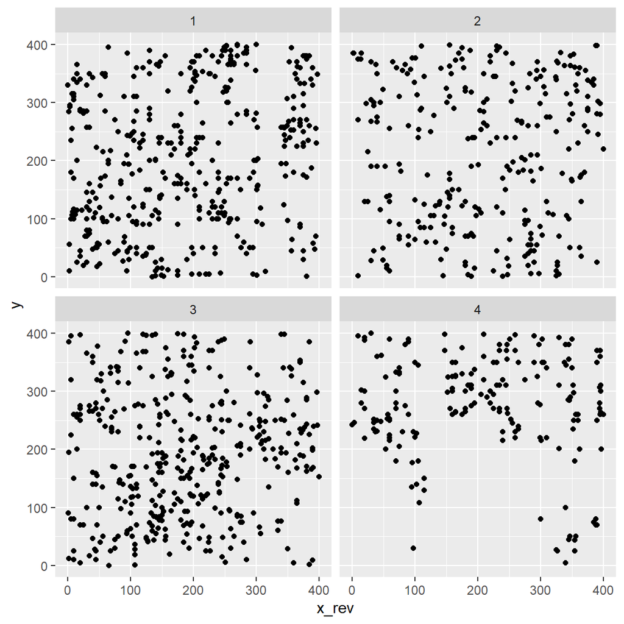

```r
disp_arb <- ggplot(carapa, aes(x_rev, y)) + # asignación de base de variables "x" y "y" a partir de coordenadas x corregidas
  geom_point() + # asignación de puntos en gráfico
  facet_wrap(carapa$Parc) # crea gráficos por parcela

disp_arb
```

Para observar la densidad de los arboles en las parcelas se puede realizar un grafico de densidad

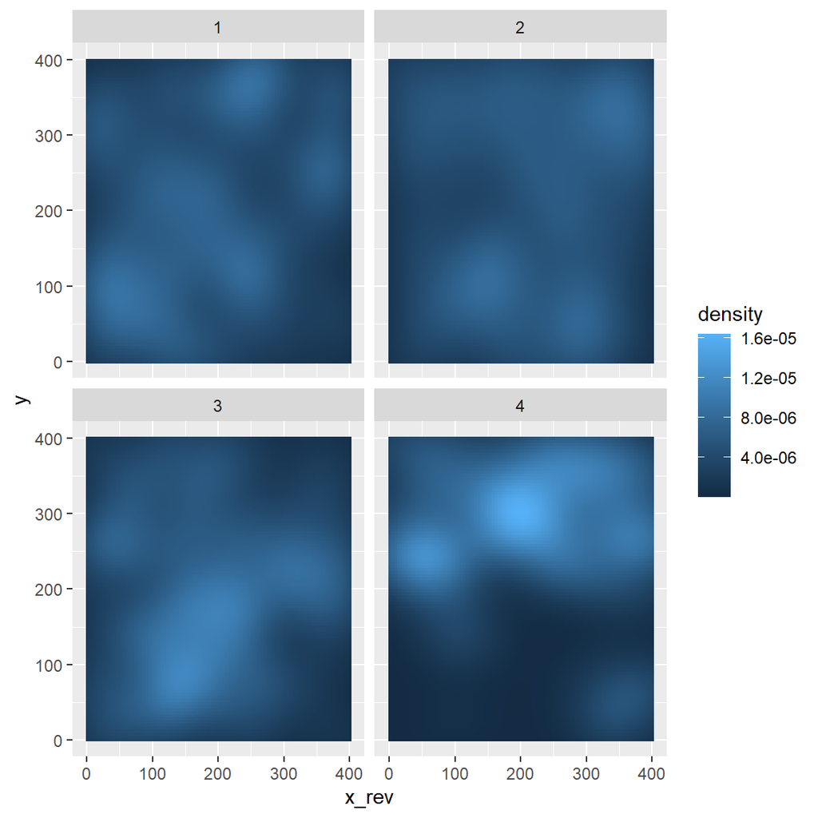

```r
dens_arb <- ggplot(carapa, aes(x_rev, y)) + # asignación de base de variables "x" y "y" a partir de coordenadas
  stat_density_2d(aes(fill = after_stat(density)), # capa densidad de puntos
                  geom = "raster", # geometría raster
                  contour = FALSE) + # eliminación de contornos en puntos
  facet_wrap(carapa$Parc) # crea gráficos por parcela
dens_arb
```

```r
# plot(density(parc1_coor)) # Esta es otra opción de densidad, pero para poner varios graficos hay que utilizar "nfrow" que permite dividir la pantalla en varios paneles
```

# Funciones spatstat

Se calculan patrones de distribución para individuos adultos (DAP > 20 cm)

```r
adultos <- carapa[carapa$DAP > "20", ] # subconjunto de individuos adultos
head(adultos)
```

```
##    Parc Sub.P NumAr x_rev   y   x  DAP Prod.    Ambiente          copa
## 1     1     5   183   200  40 -50 32.0  TRUE      Baixio  co-dominante
## 4     1     8   306   350  97 -50 21.7 FALSE Terra Firme intermediaria
## 6     3     5   260   200 119 -50 31.9  TRUE      Baixio  co-dominante
## 7     2     3    68   100 132 -50 36.0  TRUE Terra Firme  co-dominante
## 9     3     4   387   150 160 -50 33.7  TRUE      Baixio     dominante
## 10    3     5   242   200 194 -50 47.3  TRUE      Baixio     dominante
```

## Parámetro distribución R

Patrones de distribución según R. Si R=1 distribución aleatoria. R tiende a 0 distribución agregada. R cercano a 2.15 distribución uniforme.

Parcela 1:

```r
parc1 <- adultos[adultos$Parc == "1", ] # subconjunto adultos de parcela 1

# Dar formato de coordenadas a variables "x" y "y"
parc1_coor <- ppp(parc1$x_rev, # coordenadas en x
                  parc1$y, # coordenadas en y
                  window = owin(c(0,400), # delimitación coordenadas x
                                c(0,400))) # delimitación coordenadas y
clarkevans.test(parc1_coor, correction = "donnelly") # calculo de R con correción efecto borde
```

```
##
##  Clark-Evans test
##  Donnelly correction
##  Monte Carlo test based on 999 simulations of CSR with fixed n
##
## data:  parc1_coor
## R = 0.86837, p-value = 0.002
## alternative hypothesis: two-sided
```

Parcela 2:

```r
parc2 <- adultos[adultos$Parc == "2", ]
parc2_coor <- ppp(parc2$x_rev,
                  parc2$y,
                  window = owin(c(0,400),
                                c(0,400)))

clarkevans.test(parc2_coor, correction = "donnelly")
```

```
##
##  Clark-Evans test
##  Donnelly correction
##  Monte Carlo test based on 999 simulations of CSR with fixed n
##
## data:  parc2_coor
## R = 0.85661, p-value = 0.002
## alternative hypothesis: two-sided
```

Alternativa: prueba hipótesis distribución aleatoria

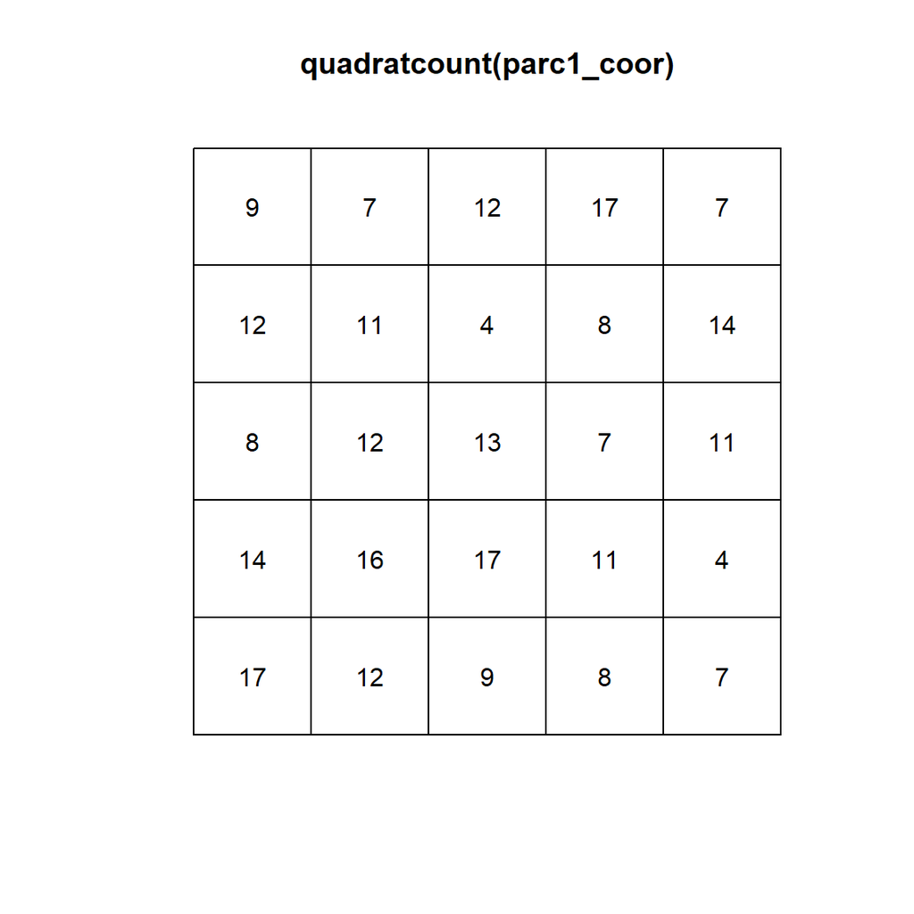

```r
plot(quadratcount(parc1_coor)) # distribución conjunto de datos
```

```r
quadrat.test(parc1_coor, nx = 5) # hipótesis nula aleatorio
```

```
##
##  Chi-squared test of CSR using quadrat counts
##
## data:  parc1_coor
## X2 = 33.094, df = 24, p-value = 0.2042
## alternative hypothesis: two.sided
##
## Quadrats: 5 by 5 grid of tiles
## Tessellation is marked
```

```r
quadrat.test(parc2_coor)
```

```
##
##  Chi-squared test of CSR using quadrat counts
##
## data:  parc2_coor
## X2 = 37.725, df = 24, p-value = 0.07398
## alternative hypothesis: two.sided
##
## Quadrats: 5 by 5 grid of tiles
## Tessellation is marked
```

**Interpretación:** Según la prueba de Clark-Evans utilizada para comprobar aleatoriedad espacial tanto en la parcela 1 como en la parcela 2 muestran un valor de R inferior a 1 (0.86837 y 0.85661 respectivamente) lo que podría indicar que hay cierto patrón de distribución agregada pero no es tan fuerte. Para comprobar la hipótesis alternativa de distribución aleatoria también se utiliza la prueba “quadrat.test” que realiza una prueba de aleatoriedad espacial completa para un patrón de puntos determinado, basándose en recuentos de cuadrantes. El resultado de esta prueba da un valor de p mayor a 0.05 para ambas parcelas (p-value = 0.2042 y p-value = 0.07398 respectivamente) lo que indica que los arboles están distribuidos aleatoriamente. Como las pruebas se contradicen no hay forma de determinar cual es la distribución real de los individuos en las parcelas, por lo tanto se requiere de más análisis para determinar la distribución real.

## Parámetro distribución Ripley´s K

Aplicación Ripley´s K para individuos en cada parcela. Esta función se utiliza para analizar el acomodo o distribución de los puntos según el tamaño de la parcela.

**Estimadores:**

- K iso: estimado isotropico corregido.
- K trans: estimado con corrección translacional.
- K border: estimado de borde corregido, menos eficiente estadisticamente, pero de menos consumo.
- K pois(theo): K teorico por Poisson para distribución **aleatoria**

```r
K1 <- Kest(parc1_coor) # Kest= función para estimadores Ripley´s K
K1 # detalles de estimadores de función
```

```
## Function value object (class 'fv')
## for the function r -> K(r)
## ..............................................................
##        Math.label       Description
## r      r                distance argument r
## theo   K[pois](r)       theoretical Poisson K(r)
## border hat(K)[bord](r)  border-corrected estimate of K(r)
## trans  hat(K)[trans](r) translation-corrected estimate of K(r)
## iso    hat(K)[iso](r)   isotropic-corrected estimate of K(r)
## ..............................................................
## Default plot formula:  .~r
## where "." stands for 'iso', 'trans', 'border', 'theo'
## Recommended range of argument r: [0, 100]
## Available range of argument r: [0, 100]
```

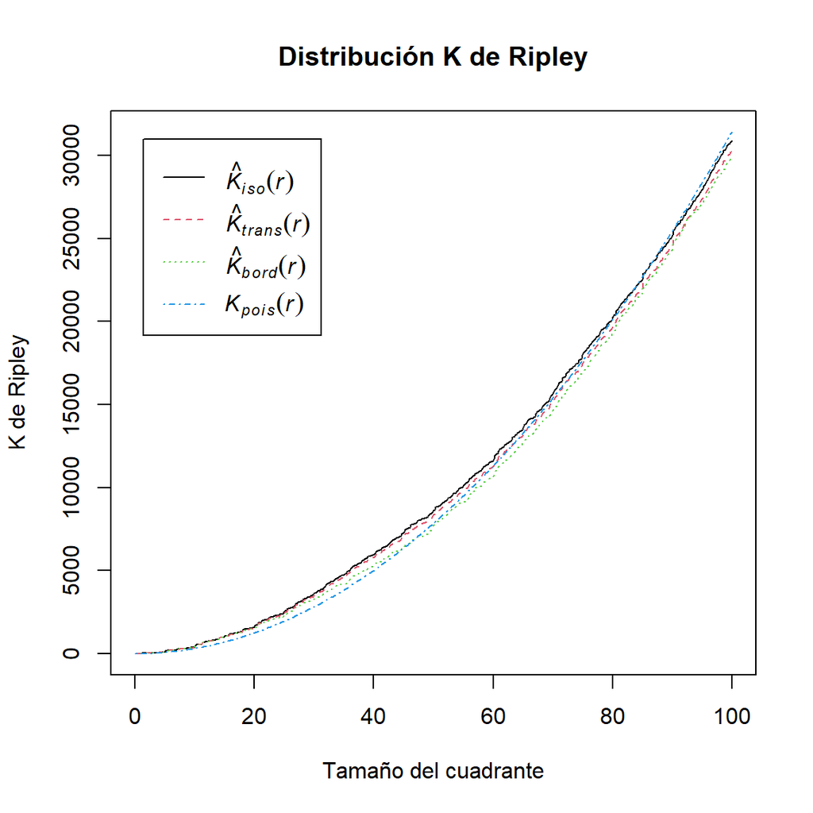

```r
plot(K1,
     xlab= "Tamaño del cuadrante",
     ylab= "K de Ripley",
     main= "Distribución K de Ripley") # graficación de estimadores
```

```r
head(as.data.frame(K1)) # previsualización de datos gráfico K1
```

```
##           r      theo   border    trans      iso
## 1 0.0000000 0.0000000 18.15912 18.02258 18.02258
## 2 0.1953125 0.1198422 18.15912 18.02258 18.02258
## 3 0.3906250 0.4793690 18.15912 18.02258 18.02258
## 4 0.5859375 1.0785802 18.15912 18.02258 18.02258
## 5 0.7812500 1.9174760 18.15912 18.02258 18.02258
## 6 0.9765625 2.9960562 18.15912 18.02258 18.02258
```

Se puede aplicar para las otras parcelas

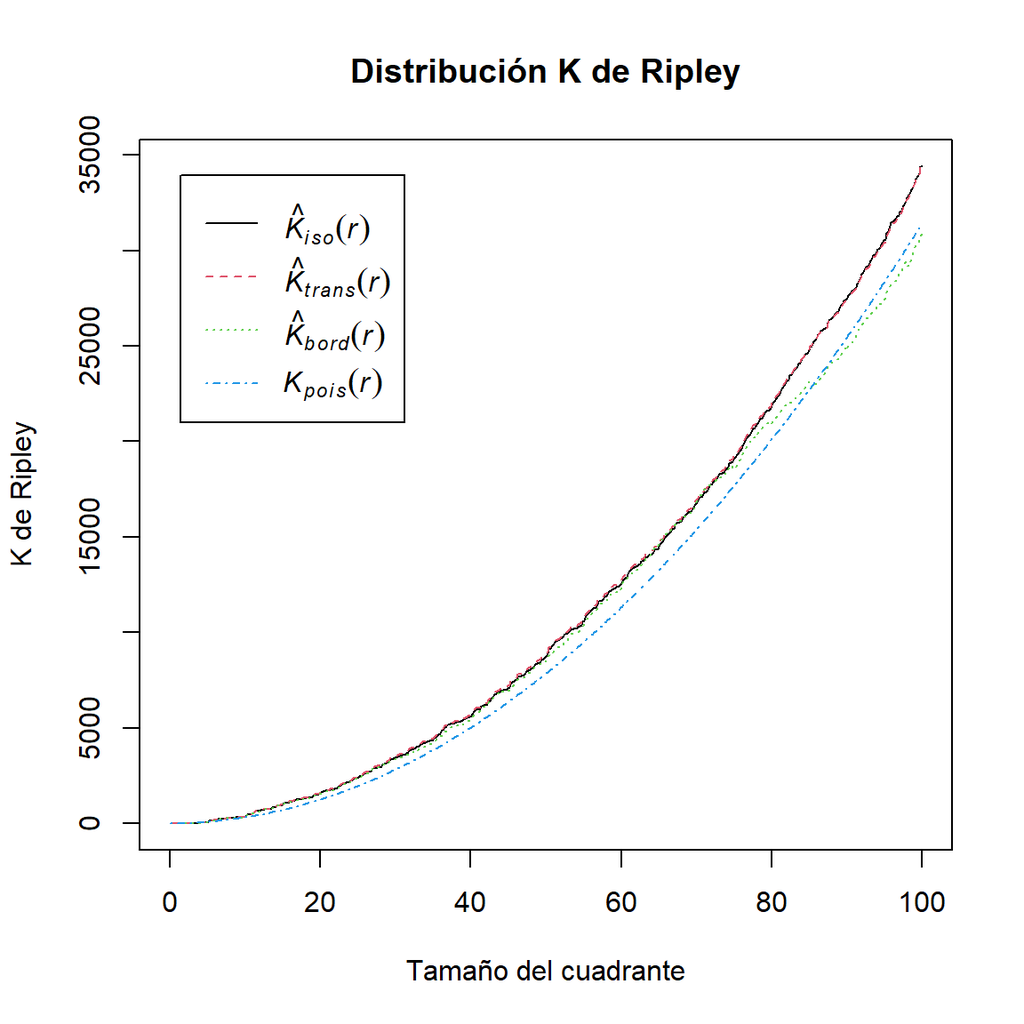

```r
# Parcela 2
K2 <- Kest(parc2_coor)
plot(K2,
     xlab= "Tamaño del cuadrante",
     ylab= "K de Ripley",
     main= "Distribución K de Ripley")
```

Estos parametros permiten visualizar las tendencias de estimadores, pero aún no pueden ser empleados como criterio de distribución. Para esto se emplea la función `envelope`.

```r
E1 <- envelope(parc1_coor, # base de datos espacial
              Kest, # función cálculo Ripleys K
              nsim=1000) # generación de puntos siguiendo patrón aleatorio a partir de Kpois(theo)
```

[output not shown]

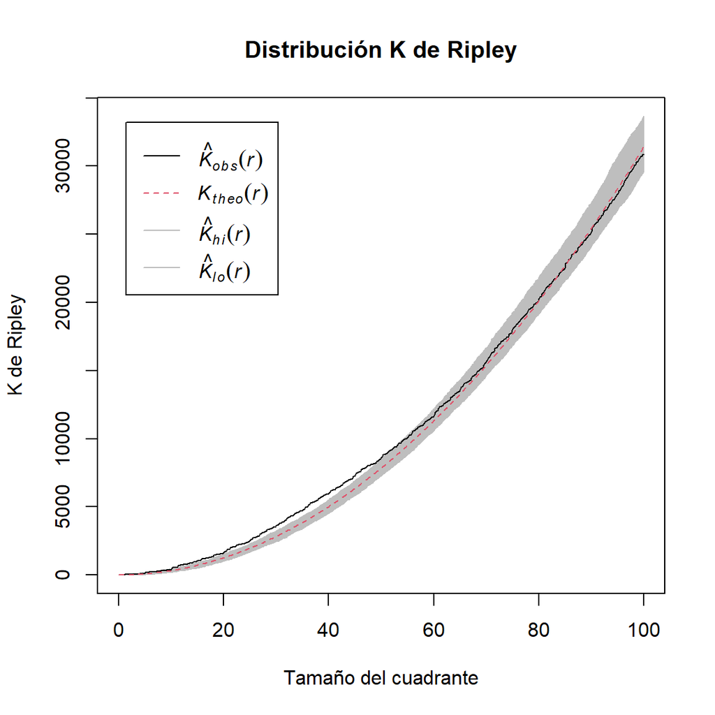

```r
plot(E1,
     xlab= "Tamaño del cuadrante",
     ylab= "K de Ripley",
     main= "Distribución K de Ripley")
```

La zona sombreada muestra los valores más altos y bajos generados a partir de Kpois. Mientras la linea continua (Kr observada) se encuentre dentro de la zona sombreada la distribución es aleatoria, sobre la zona sombreada la distribución es agregada y bajo la misma la distribución es uniforme.

```r
E2 <- envelope(parc2_coor,
              Kest,
              nsim=1000)
```

[output not shown]

```r
E2.1 <- envelope(parc2_coor,
              Kest,
              nsim=100)
```

```
## Generating 100 simulations of CSR  ...
## 1, 2, 3, 4, 5, 6, 7, 8, 9, 10, 11, 12, 13, 14, 15, 16, 17, 18, 19, 20, 21, 22, 23, 24, 25, 26, 27, 28, 29, 30, 31, 32, 33, 34, 35, 36, 37, 38, 39, 40,
## 41, 42, 43, 44, 45, 46, 47, 48, 49, 50, 51, 52, 53, 54, 55, 56, 57, 58, 59, 60, 61, 62, 63, 64, 65, 66, 67, 68, 69, 70, 71, 72, 73, 74, 75, 76, 77, 78, 79, 80,
## 81, 82, 83, 84, 85, 86, 87, 88, 89, 90, 91, 92, 93, 94, 95, 96, 97, 98, 99,  100.
##
## Done.
```

```r
E2.2 <- envelope(parc2_coor,
              Kest,
              nsim=10)
```

```
## Generating 10 simulations of CSR  ...
## 1, 2, 3, 4, 5, 6, 7, 8, 9,  10.
##
## Done.
```

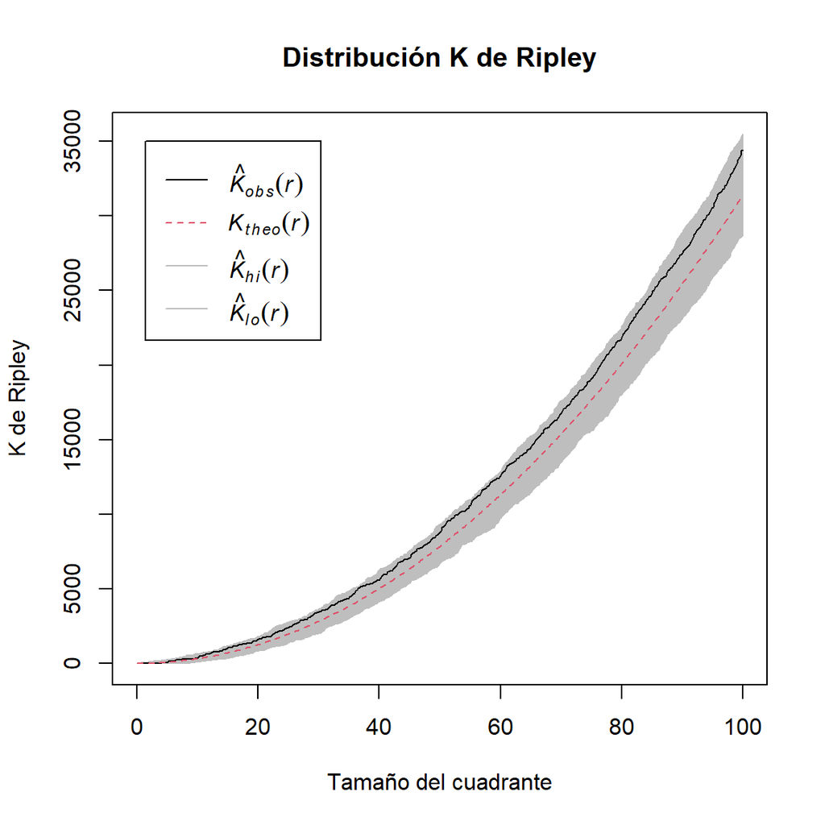

```r
plot(E2,
     xlab= "Tamaño del cuadrante",
     ylab= "K de Ripley",
     main= "Distribución K de Ripley")
```

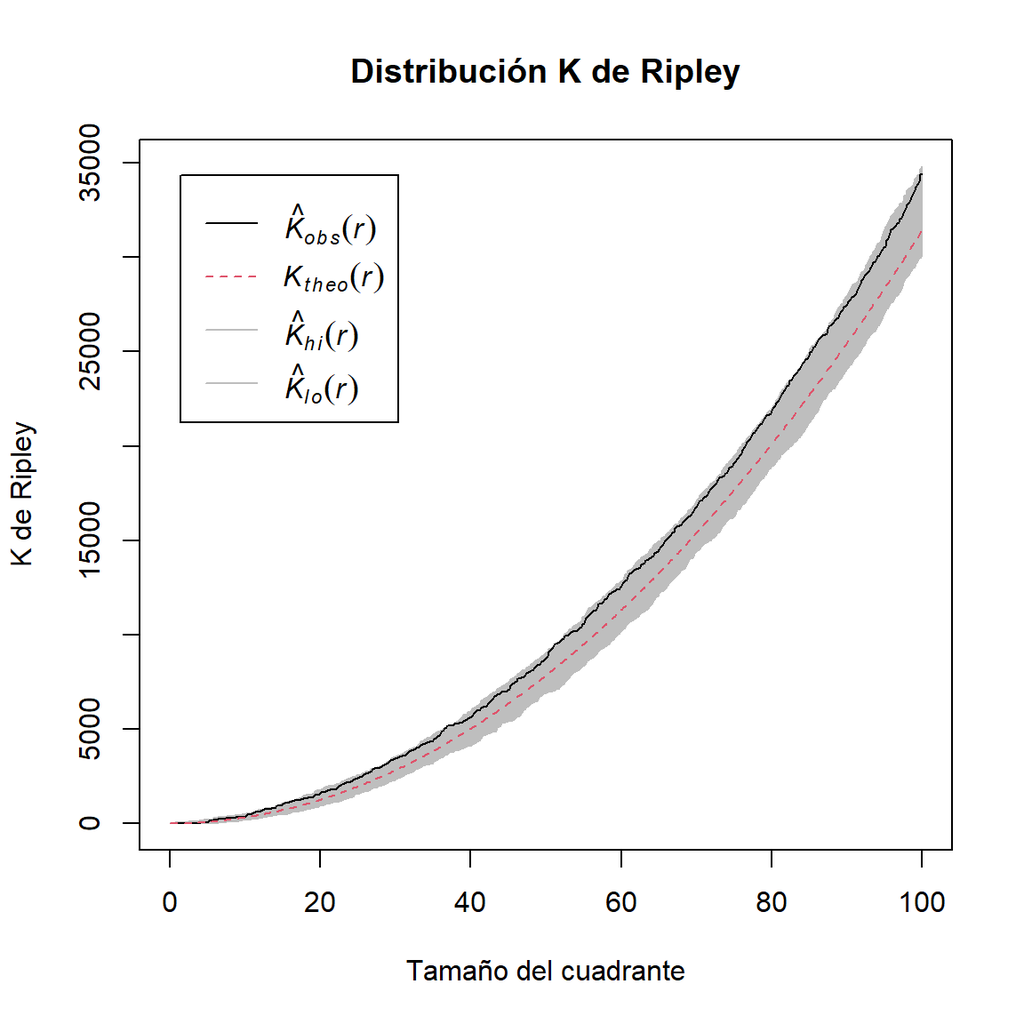

```r
plot(E2.1,
     xlab= "Tamaño del cuadrante",
     ylab= "K de Ripley",
     main= "Distribución K de Ripley")
```

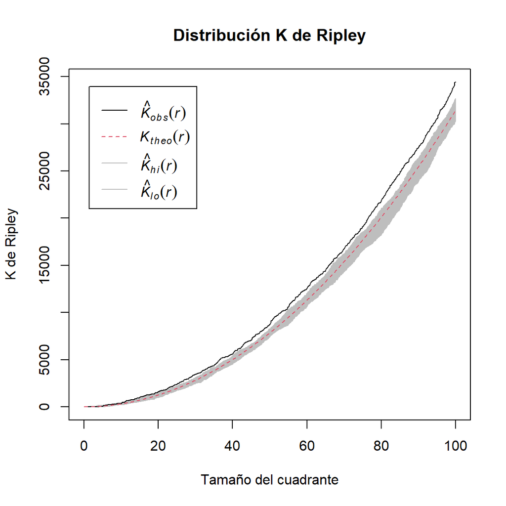

```r
plot(E2.2,
     xlab= "Tamaño del cuadrante",
     ylab= "K de Ripley",
     main= "Distribución K de Ripley")
```

## Función Besag’s L

La transformación de Besag’s L toma los estimados de Ripley’s K y los convierte a distribución lineal con respecto a una distribución aleatoria.

Besag’s L es usado para determinar el patrón de distribución. Para esto se coloca el estimado de la distribución aleatoria con pendiente “0” y valor “0” en el eje “y”, los valores negativos indican distribuciones uniformes y valores positivos indican distribucioness agrupadas

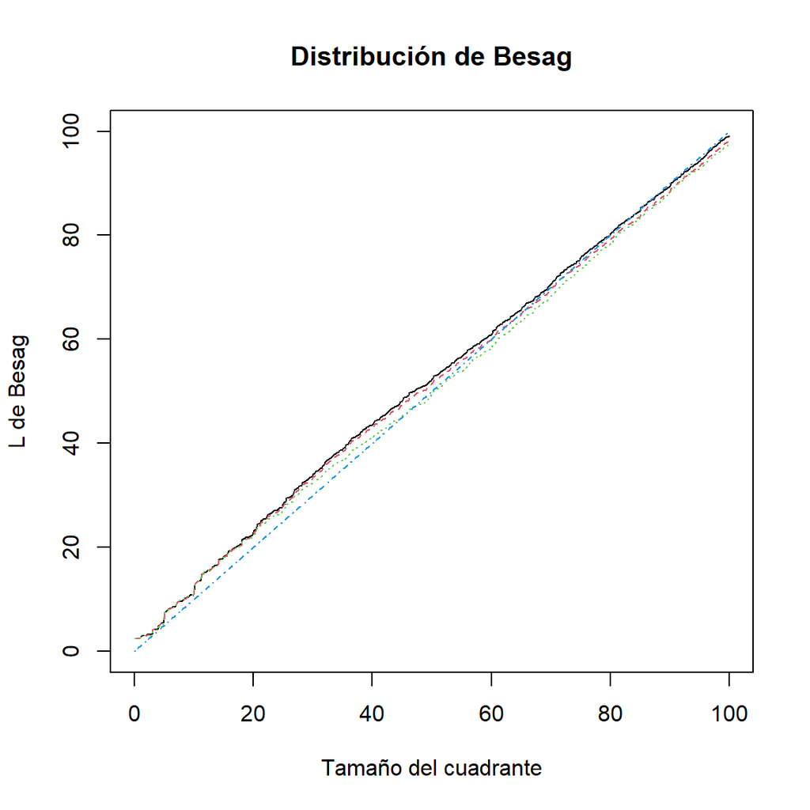

```r
L <- sqrt(K1/pi) # transformación Besag's L
plot(L,
     xlab= "Tamaño del cuadrante",
     ylab= "L de Besag",
     main= "Distribución de Besag",
     legend = FALSE)
```

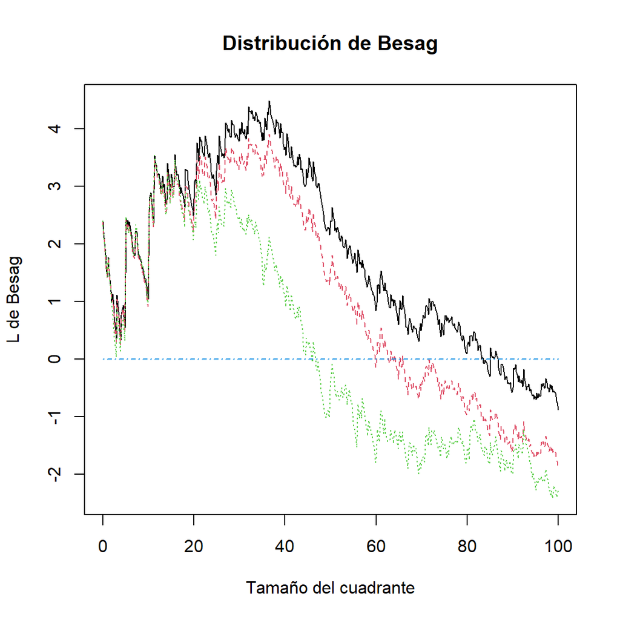

```r
L <- sqrt(K1/pi)
plot(L, . - theo ~ r,
     xlab= "Tamaño del cuadrante",
     ylab= "L de Besag",
     main= "Distribución de Besag",
     legend= FALSE)
```

Para agregar intervalos de valores aleatorios se emplea `envelop`

```r
A2 <- envelope(parc1_coor, global=FALSE, nsim=10, transform=expression(sqrt(./pi)))
```

```
## Generating 10 simulations of CSR  ...
## 1, 2, 3, 4, 5, 6, 7, 8, 9,  10.
##
## Done.
```